# Capstone: Project Report

Eric Henderson

August 31, 2017

# Report Summary

This report details the construction of prediction data used to suggest the next word to follow a user provided phrase. A collection of text from blogs, news, and twitter was used as source material for the construction of the prediction model. Exploration finds the three source text files varied in number of lines and total words. A small random sample of each text file is selected and combined into a new source document for relational analysis. The combined document is then processed to prepare for analysis. Relationships within the text are analyzed by evaluating N-grams of lengths from one to six. N-grams are created for text with, and without, common words (stop words) for comparison. The N-grams generated in this report provide key insights into the nature of the word relations as well as creating the data needed for a predictive text model. The primary insight being that stop words may not be easily discarded and may play a large role in processing input for the predictive model. Ultimately, n-grams with stop words included are used for the predictive tables.

# Data Loading

Packages used in this report and the supplied data files are loaded for use. The files are each roughly a quarter of a gigabyte in size once loaded into R.

```r
# load needed packages
library(ggplot2)
library(tm)
library(stylo)
library(stringi)
```

```r
# read in text data
con <- file("en_US.blogs.txt", "rb")
blog <- readLines(con)
close(con)
con <- file("en_US.news.txt", "rb")
news <- readLines(con)
close(con)
con <- file("en_US.twitter.txt", "rb")
twitter <- readLines(con)
close(con)
con <- url("http://www.bannedwordlist.com/lists/swearWords.txt")
cursewords <- readLines(con)
close(con)

rm(con)
```

# Data Exploration

The supplied text comes in three files, where each file contains text from a different source. Text sources include “blog”, “twitter”, and “news”. In this section, an overview of the files will be presented, focusing on total lines per file, total words per file, and average words per line.

### Total Lines

The twitter text contains over double the number of lines of text compared to the blog text and news text. News and blog texts have similar amounts of lines.

```r
# Calculate total lines per file and display
lines <- data.frame(c("Blog", "News", "Twitter"),
                    c(NROW(blog), NROW(news), NROW(twitter)))
names(lines) <- c("Text", "Lines")
lines
```

```
##      Text   Lines
## 1    Blog  899288
## 2    News 1010242
## 3 Twitter 2360148
```

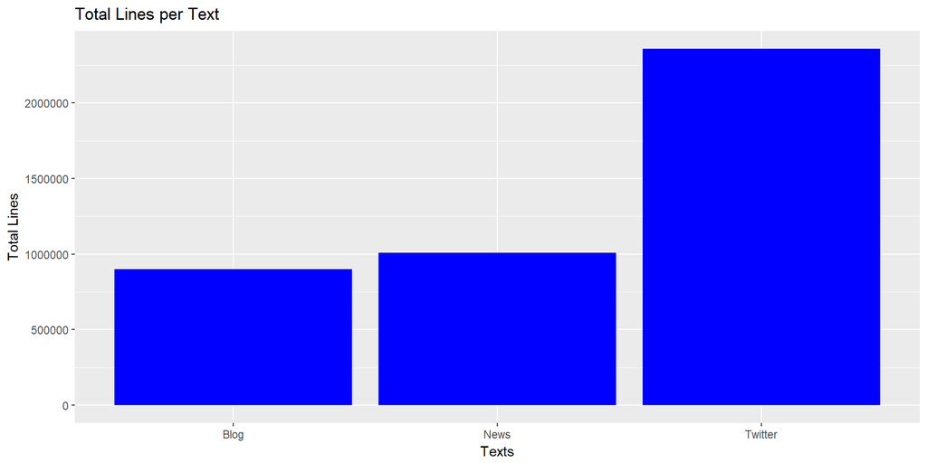

```r
ggplot (lines, aes(x = Text, y = Lines)) +
  geom_bar( stat = "Identity" , fill = "blue" ) +
  labs(title = "Total Lines per Text") +
  xlab( "Texts" ) + ylab( "Total Lines" )
```

### Total Words

While the twitter text has double the lines of the other texts, it has fewer total words than either of the others (containing a total word size roughly 80% of the number of words found in the blog text). Blog and news texts have similar total word numbers.

```r
# Calculate total words per file and display
tempBlog <- unlist(strsplit(blog, split=" "))
tempNews <- unlist(strsplit(news, split=" "))
tempTwitter <- unlist(strsplit(twitter, split=" "))
words <- data.frame(c("Blog", "News", "Twitter"),
                    c(NROW(tempBlog), NROW(tempNews), NROW(tempTwitter)))
names(words) <- c("Text", "Words")
rm(tempBlog)
rm(tempNews)
rm(tempTwitter)
words
```

```
##      Text    Words
## 1    Blog 37334131
## 2    News 34372530
## 3 Twitter 30373543
```

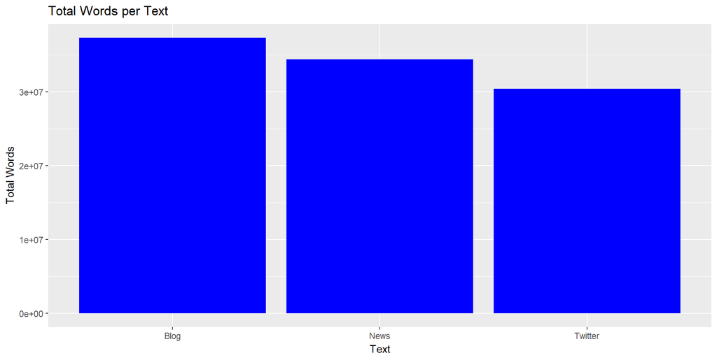

```r
ggplot (words, aes(x = Text, y = Words)) +
  geom_bar( stat = "Identity" , fill = "blue" ) +
  labs(title = "Total Words per Text") +
  xlab( "Text" ) + ylab( "Total Words" )
```

### Words per Line

As expected, given the high number of lines and lower total word count, the twitter text has the lowest ration of words to lines. The blog text, which had slightly more words and slightly fewer lines than the news text, comes in with the highest ratio.

```r
# Calculate average words per line
ratio <- data.frame(c("Blog", "News", "Twitter"),
                    c(words$Words[1]/lines$Lines[1],
                      words$Words[2]/lines$Lines[2],
                      words$Words[3]/lines$Lines[3]))
names(ratio) <- c("Text", "Ratio")
ratio
```

```
##      Text    Ratio
## 1    Blog 41.51521
## 2    News 34.02406
## 3 Twitter 12.86934
```

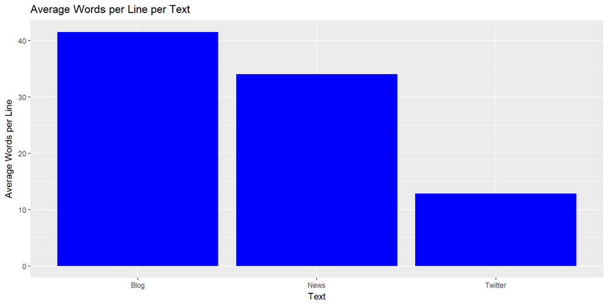

```r
ggplot (ratio, aes(x = Text, y = Ratio)) +
  geom_bar( stat = "Identity" , fill = "blue" ) +
  labs(title = "Average Words per Line per Text") +
  xlab( "Text" ) + ylab( "Average Words per Line" )
```

```r
rm(ratio)
rm(lines)
rm(words)
```

# Corpus Creation

This section details the creation and processing of the corpus text, which will be the source text used for creation of the predictive text model.

### Sampling and Combine

Given the size of the data sets a random subset of each text source will be taken and then combined to form the corpus. Different size samples are used for different sized n-grams. Much of the diversity of lower sized n-grams is captured in smaller samples. Finding frequent n-grams of larger sizes requires larger sample sizes. Sample sizes range from ten percent, for 2-grams, to fourty percent for 6-grams.

```r
# Sample a portion of the text data
blogRows <- NROW(blog)
blogSubSet <- sample(blog, blogRows*.1)
newsRows <- NROW(news)
newsSubSet <- sample(news, newsRows*.1)
twitterRows <- NROW(twitter)
twitterSubSet <- sample(twitter, twitterRows*.1)

combine <- c(blogSubSet, newsSubSet, twitterSubSet)

blogRows <- NROW(blog)
blogSubSet <- sample(blog, blogRows*.15)
newsRows <- NROW(news)
newsSubSet <- sample(news, newsRows*.15)
twitterRows <- NROW(twitter)
twitterSubSet <- sample(twitter, twitterRows*.15)

combine2 <- c(blogSubSet, newsSubSet, twitterSubSet)

blogRows <- NROW(blog)
blogSubSet <- sample(blog, blogRows*.25)
newsRows <- NROW(news)
newsSubSet <- sample(news, newsRows*.25)
twitterRows <- NROW(twitter)
twitterSubSet <- sample(twitter, twitterRows*.25)

combine3 <- c(blogSubSet, newsSubSet, twitterSubSet)

blogRows <- NROW(blog)
blogSubSet <- sample(blog, blogRows*.3)
newsRows <- NROW(news)
newsSubSet <- sample(news, newsRows*.3)
twitterRows <- NROW(twitter)
twitterSubSet <- sample(twitter, twitterRows*.3)

combine4 <- c(blogSubSet, newsSubSet, twitterSubSet)

blogRows <- NROW(blog)
blogSubSet <- sample(blog, blogRows*.4)
newsRows <- NROW(news)
newsSubSet <- sample(news, newsRows*.4)
twitterRows <- NROW(twitter)
twitterSubSet <- sample(twitter, twitterRows*.4)

combine5 <- c(blogSubSet, newsSubSet, twitterSubSet)

rm(blog)
rm(blogRows)
rm(news)
rm(newsRows)
rm(twitter)
rm(twitterRows)
rm(blogSubSet)
rm(newsSubSet)
rm(twitterSubSet)

preCorpus <- unlist(strsplit(combine, split=" "))
preCorpus2 <- unlist(strsplit(combine2, split=" "))
preCorpus3 <- unlist(strsplit(combine3, split=" "))
preCorpus4 <- unlist(strsplit(combine4, split=" "))
preCorpus5 <- unlist(strsplit(combine5, split=" "))
```

### Processing and Clean Up

The corpus is processed to remove unwanted symbols and words, as well as reducing all characters to lower case. Two types of corpus data sets are created, one with common words and one without. Corpus data with stop words included is further seperated into sets for each sample size. Curse words are stripped from all text sets. After processing the two corpus types have any empty strings (left over from processing) removed.

```r
# Construct and process corpus
preCorpus <- sapply(preCorpus, tolower)
preCorpus <- gsub("â€™", "'", preCorpus)
#preCorpus <- gsub("[[:punct:]]", "", preCorpus, perl = TRUE)
preCorpus <- gsub("[^'[:lower:]]", "", preCorpus)
preCorpus <- gsub("â|€|™|˜|œ|„|Â", "", preCorpus)
preCorpus <- gsub("^'*$", "", preCorpus)
preCorpus <- gsub("^'s$", "", preCorpus)
cursewords <- paste(cursewords, collapse = "$|^")
cursewords <- paste('^', cursewords, '$', collapse = '')
cursewords <- gsub(" ", "", cursewords)
preCorpus <- gsub(cursewords, "", preCorpus)
# find all strings that are empty or all numeric, then remove
numsAndEmpty <- grep("^[[:digit:]]*$", preCorpus)
preCorpus <- preCorpus[-numsAndEmpty]
#stops <- grep(paste(stopwords("english"), collapse = "|"), preCorpus)
#theCorpusWithoutStops <- preCorpus[-stops]
modStops <- paste(stopwords("english"), collapse = "$|^")
modStops <- paste('^', modStops, '$', collapse = '')
modStops <- gsub(" ", "", modStops)
theCorpusWithoutStops <- gsub(modStops, "", preCorpus)
empties <- grep("^$", theCorpusWithoutStops)
theCorpusWithoutStops <- theCorpusWithoutStops[-empties]
theCorpus <- preCorpus

preCorpus2 <- sapply(preCorpus2, tolower)
preCorpus2 <- gsub("â€™", "'", preCorpus2)
preCorpus2 <- gsub("[^'[:lower:]]", "", preCorpus2)
preCorpus2 <- gsub("â|€|™|˜|œ|„|Â", "", preCorpus2)
preCorpus2 <- gsub("^'*$", "", preCorpus2)
preCorpus2 <- gsub("^'s$", "", preCorpus2)
preCorpus2 <- gsub(cursewords, "", preCorpus2)
# find all strings that are empty or all numeric, then remove
numsAndEmpty <- grep("^[[:digit:]]*$", preCorpus2)
preCorpus2 <- preCorpus2[-numsAndEmpty]
theCorpus2 <- preCorpus2

preCorpus3 <- sapply(preCorpus3, tolower)
preCorpus3 <- gsub("â€™", "'", preCorpus3)
preCorpus3 <- gsub("[^'[:lower:]]", "", preCorpus3)
preCorpus3 <- gsub("â|€|™|˜|œ|„|Â", "", preCorpus3)
preCorpus3 <- gsub("^'*$", "", preCorpus3)
preCorpus3 <- gsub("^'s$", "", preCorpus3)
preCorpus3 <- gsub(cursewords, "", preCorpus3)
# find all strings that are empty or all numeric, then remove
numsAndEmpty <- grep("^[[:digit:]]*$", preCorpus3)
preCorpus3 <- preCorpus3[-numsAndEmpty]
theCorpus3 <- preCorpus3

preCorpus4 <- sapply(preCorpus4, tolower)
preCorpus4 <- gsub("â€™", "'", preCorpus4)
preCorpus4 <- gsub("[^'[:lower:]]", "", preCorpus4)
preCorpus4 <- gsub("â|€|™|˜|œ|„|Â", "", preCorpus4)
preCorpus4 <- gsub("^'*$", "", preCorpus4)
preCorpus4 <- gsub("^'s$", "", preCorpus4)
preCorpus4 <- gsub(cursewords, "", preCorpus4)
# find all strings that are empty or all numeric, then remove
numsAndEmpty <- grep("^[[:digit:]]*$", preCorpus4)
preCorpus4 <- preCorpus4[-numsAndEmpty]
theCorpus4 <- preCorpus4

preCorpus5 <- sapply(preCorpus5, tolower)
preCorpus5 <- gsub("â€™", "'", preCorpus5)
preCorpus5 <- gsub("[^'[:lower:]]", "", preCorpus5)
preCorpus5 <- gsub("â|€|™|˜|œ|„|Â", "", preCorpus5)
preCorpus5 <- gsub("^'*$", "", preCorpus5)
preCorpus5 <- gsub("^'s$", "", preCorpus5)
preCorpus5 <- gsub(cursewords, "", preCorpus5)
# find all strings that are empty or all numeric, then remove
numsAndEmpty <- grep("^[[:digit:]]*$", preCorpus5)
preCorpus5 <- preCorpus5[-numsAndEmpty]
theCorpus5 <- preCorpus5
```

# Analyzing Corpus via N-grams

N-grams are constructed in this section of varying length to see which sequence of words are most frequent and to begin to understand which words are likely to appear after others. N-grams such as these will be used as part of the predictive model.

### Unigrams

Unigrams may be too short to assist with prediction, other then to suggest a starting word, but are helpful as part of exploring the contents of the corpus and getting a sense of what words are present. Unsurprisingly the unigrams from the corpus including common words is dominated by those common words.

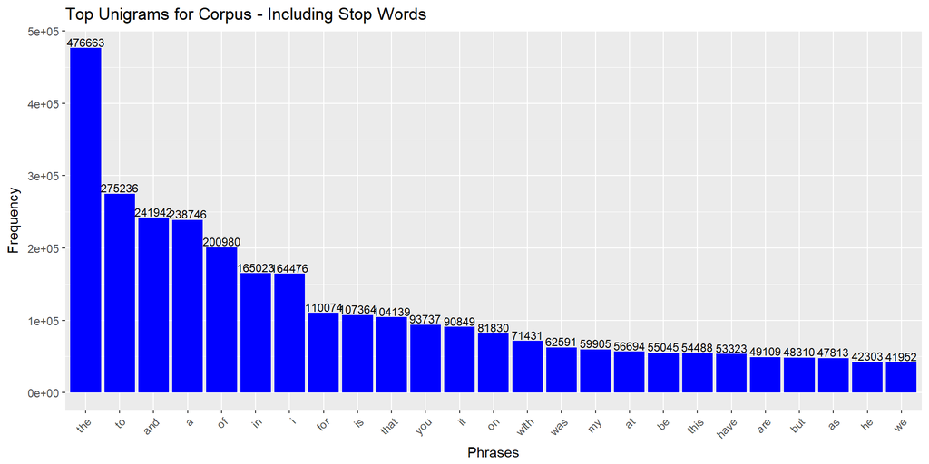

```r
# Create Unigram and display top 25
unigram <- data.frame(table(make.ngrams(theCorpus, ngram.size = 1)))
colnames(unigram)<-c("Phrase","Frequency")
sortedUnigram <- unigram[order(-unigram$Freq),]
topUnigram <- sortedUnigram[1:25,]
colnames(topUnigram)<-c("Phrase","Frequency")
topUnigram$Phrase <- factor(topUnigram$Phrase, levels = topUnigram$Phrase)

ggplot (topUnigram, aes(x = Phrase, y= Frequency )) +
  geom_bar( stat = "Identity" , fill = "blue" ) +
  geom_text( aes (label = Frequency ) , vjust = - 0.20, size = 3 ) +
  xlab( "Phrases" ) + ylab( "Frequency" ) +
  labs(title = "Top Unigrams for Corpus - Including Stop Words") +
  theme ( axis.text.x = element_text ( angle = 45 , hjust = 1 ) )
```

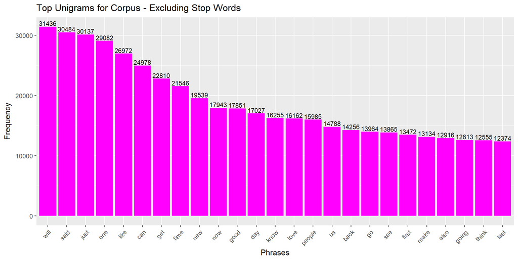

```r
# Create Unigram, with stops removed, and display top 25
unigramws <- data.frame(table(make.ngrams(theCorpusWithoutStops, ngram.size = 1)))
colnames(unigramws)<-c("Phrase","Frequency")
sortedUnigramws <- unigramws[order(-unigramws$Freq),]
topUnigramws <- sortedUnigramws[1:25,]
colnames(topUnigramws)<-c("Phrase","Frequency")
topUnigramws$Phrase <- factor(topUnigramws$Phrase, levels = topUnigramws$Phrase)

ggplot (topUnigramws, aes(x = Phrase, y= Frequency )) +
  geom_bar( stat = "Identity" , fill = "magenta" ) +
  geom_text( aes (label = Frequency ) , vjust = - 0.20, size = 3 ) +
  xlab( "Phrases" ) + ylab( "Frequency" ) +
  labs(title = "Top Unigrams for Corpus - Excluding Stop Words") +
  theme ( axis.text.x = element_text ( angle = 45 , hjust = 1 ) )
```

### Bigrams

Similar to the unigrams the bigrams for the corpus including common words is largely comprised of common word pairings. In the bigrams for the corpus without stop words we see some of the benefit of N-grams for text prediction, with many showing strong candidate suggestions for words based on the word prior.

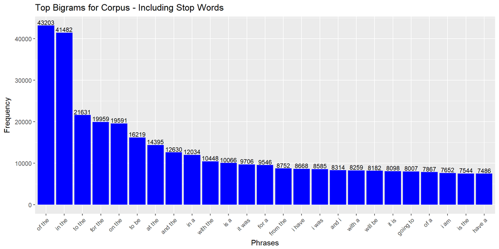

```r
# Create Bigram and display top 25
bigram <- data.frame(table(make.ngrams(theCorpus, ngram.size = 2)))
colnames(bigram)<-c("Phrase","Frequency")
sortedBigram <- bigram[order(-bigram$Freq),]
topBigram <- sortedBigram[1:25,]
colnames(topBigram)<-c("Phrase","Frequency")
topBigram$Phrase <- factor(topBigram$Phrase, levels = topBigram$Phrase)

ggplot (topBigram, aes(x = Phrase, y= Frequency )) +
  geom_bar( stat = "Identity" , fill = "blue" ) +
  geom_text( aes (label = Frequency ) , vjust = - 0.20, size = 3 ) +
  xlab( "Phrases" ) + ylab( "Frequency" ) +
  labs(title = "Top Bigrams for Corpus - Including Stop Words") +
  theme ( axis.text.x = element_text ( angle = 45 , hjust = 1 ) )
```

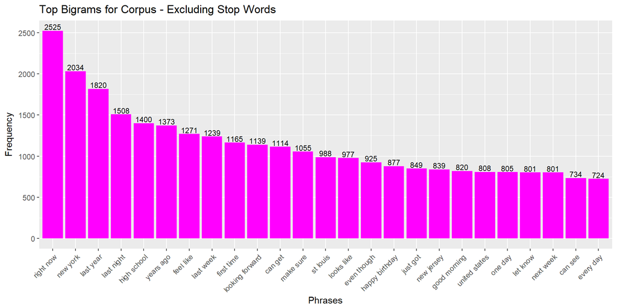

```r
# Create Bigram, with stops removed, and display top 25
bigramws <- data.frame(table(make.ngrams(theCorpusWithoutStops, ngram.size = 2)))
colnames(bigramws)<-c("Phrase","Frequency")
sortedBigramws <- bigramws[order(-bigramws$Freq),]
topBigramws <- sortedBigramws[1:25,]
colnames(topBigramws)<-c("Phrase","Frequency")
topBigramws$Phrase <- factor(topBigramws$Phrase, levels = topBigramws$Phrase)

ggplot (topBigramws, aes(x = Phrase, y= Frequency )) +
  geom_bar( stat = "Identity" , fill = "magenta" ) +
  geom_text( aes (label = Frequency ) , vjust = - 0.20, size = 3 ) +
  xlab( "Phrases" ) + ylab( "Frequency" ) +
  labs(title = "Top Bigrams for Corpus - Excluding Stop Words") +
  theme ( axis.text.x = element_text ( angle = 45 , hjust = 1 ) )
```

### Trigrams

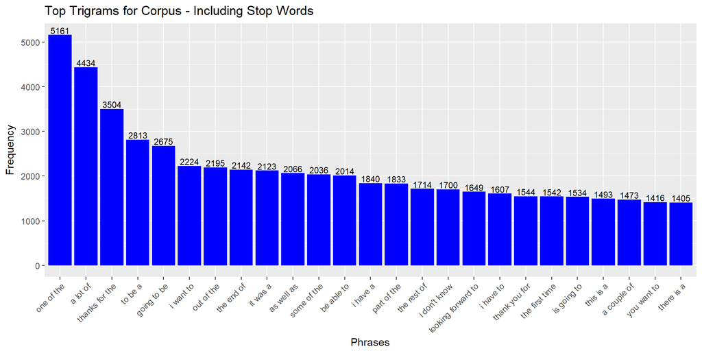

```r
# Create Trigram and display top 25
trigram <- data.frame(table(make.ngrams(theCorpus2, ngram.size = 3)))
colnames(trigram)<-c("Phrase","Frequency")
sortedTrigram <- trigram[order(-trigram$Freq),]
topTrigram <- sortedTrigram[1:25,]
colnames(topTrigram)<-c("Phrase","Frequency")
topTrigram$Phrase <- factor(topTrigram$Phrase, levels = topTrigram$Phrase)

ggplot (topTrigram, aes(x = Phrase, y= Frequency )) +
  geom_bar( stat = "Identity" , fill = "blue" ) +
  geom_text( aes (label = Frequency ) , vjust = - 0.20, size = 3 ) +
  xlab( "Phrases" ) + ylab( "Frequency" ) +
  labs(title = "Top Trigrams for Corpus - Including Stop Words") +
  theme ( axis.text.x = element_text ( angle = 45 , hjust = 1 ) )
```

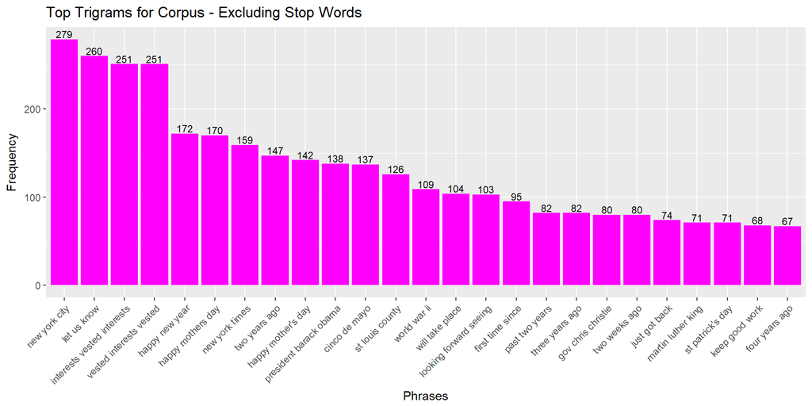

```r
# Create Trigram, with stops removed, and display top 25
trigramws <- data.frame(table(make.ngrams(theCorpusWithoutStops, ngram.size = 3)))
colnames(trigramws)<-c("Phrase","Frequency")
sortedTrigramws <- trigramws[order(-trigramws$Freq),]
topTrigramws <- sortedTrigramws[1:25,]
colnames(topTrigramws)<-c("Phrase","Frequency")
topTrigramws$Phrase <- factor(topTrigramws$Phrase, levels = topTrigramws$Phrase)

ggplot (topTrigramws, aes(x = Phrase, y= Frequency )) +
  geom_bar( stat = "Identity" , fill = "magenta" ) +
  geom_text( aes (label = Frequency ) , vjust = - 0.20, size = 3 ) +
  xlab( "Phrases" ) + ylab( "Frequency" ) +
  labs(title = "Top Trigrams for Corpus - Excluding Stop Words") +
  theme ( axis.text.x = element_text ( angle = 45 , hjust = 1 ) )
```

### Quadgrams

As we increase n-gram size we continue to see more predictive utility from the text data containing stop words. Interestingly the non-stop word data is starting to become cluttered with non-sense phrases that are clearly not part of normal written works, but instead part of meta information within the source text.

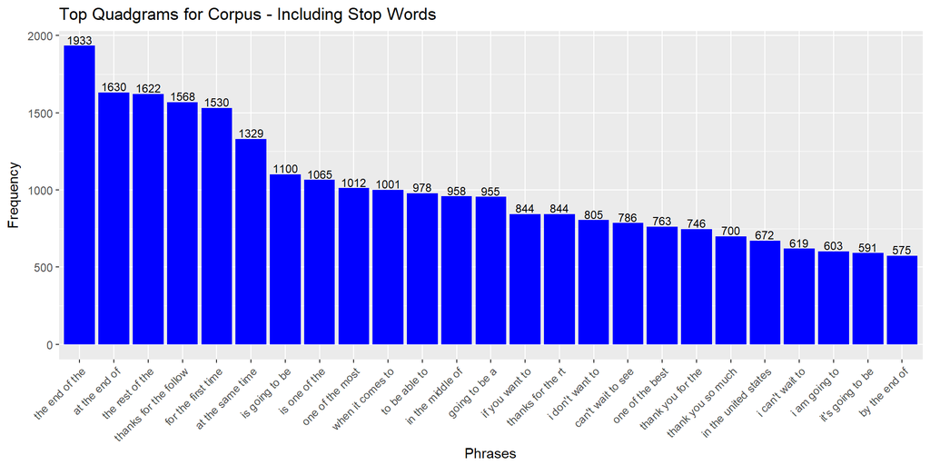

```r
# Create quadgram and display top 25
quadgram <- data.frame(table(make.ngrams(theCorpus3, ngram.size = 4)))
colnames(quadgram)<-c("Phrase","Frequency")
sortedQuadgram <- quadgram[order(-quadgram$Freq),]
topQuadgram <- sortedQuadgram[1:25,]
colnames(topQuadgram)<-c("Phrase","Frequency")
topQuadgram$Phrase <- factor(topQuadgram$Phrase, levels = topQuadgram$Phrase)

ggplot (topQuadgram, aes(x = Phrase, y= Frequency )) +
  geom_bar( stat = "Identity" , fill = "blue" ) +
  geom_text( aes (label = Frequency ) , vjust = - 0.20, size = 3 ) +
  xlab( "Phrases" ) + ylab( "Frequency" ) +
  labs(title = "Top Quadgrams for Corpus - Including Stop Words") +
  theme ( axis.text.x = element_text ( angle = 45 , hjust = 1 ) )
```

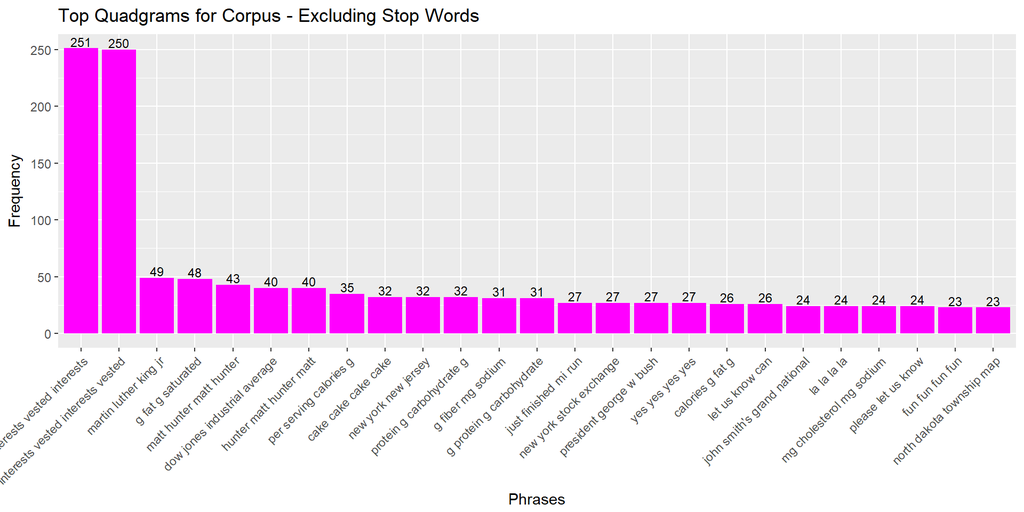

```r
# Create quadgram, with stops removed, and display top 25
quadgramws <- data.frame(table(make.ngrams(theCorpusWithoutStops, ngram.size = 4)))
colnames(quadgramws)<-c("Phrase","Frequency")
sortedQuadgramws <- quadgramws[order(-quadgramws$Freq),]
topQuadgramws <- sortedQuadgramws[1:25,]
colnames(topQuadgramws)<-c("Phrase","Frequency")
topQuadgramws$Phrase <- factor(topQuadgramws$Phrase, levels = topQuadgramws$Phrase)

ggplot (topQuadgramws, aes(x = Phrase, y= Frequency )) +
  geom_bar( stat = "Identity" , fill = "magenta" ) +
  geom_text( aes (label = Frequency ) , vjust = - 0.20, size = 3 ) +
  xlab( "Phrases" ) + ylab( "Frequency" ) +
  labs(title = "Top Quadgrams for Corpus - Excluding Stop Words") +
  theme ( axis.text.x = element_text ( angle = 45 , hjust = 1 ) )
```

### Pentagrams

Much of the same observations present in quadgrams are relevant to pentagrams. Non-stop word n-grams continues to be intermixed with repeated meta information in the source text, however some now meta text phrases seem to be making their way into the more frequent pentagrams.

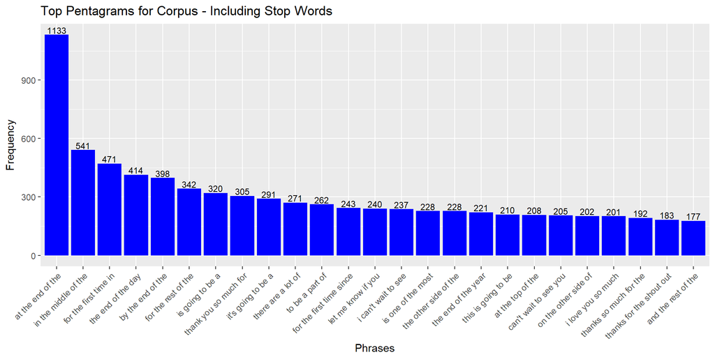

```r
# Create pentagram and display top 25
pentagram <- data.frame(table(make.ngrams(theCorpus4, ngram.size = 5)))
colnames(pentagram)<-c("Phrase","Frequency")
sortedPentagram <- pentagram[order(-pentagram$Freq),]
topPentagram <- sortedPentagram[1:25,]
colnames(topPentagram)<-c("Phrase","Frequency")
topPentagram$Phrase <- factor(topPentagram$Phrase, levels = topPentagram$Phrase)

ggplot (topPentagram, aes(x = Phrase, y= Frequency )) +
  geom_bar( stat = "Identity" , fill = "blue" ) +
  geom_text( aes (label = Frequency ) , vjust = - 0.20, size = 3 ) +
  xlab( "Phrases" ) + ylab( "Frequency" ) +
  labs(title = "Top Pentagrams for Corpus - Including Stop Words") +
  theme ( axis.text.x = element_text ( angle = 45 , hjust = 1 ) )
```

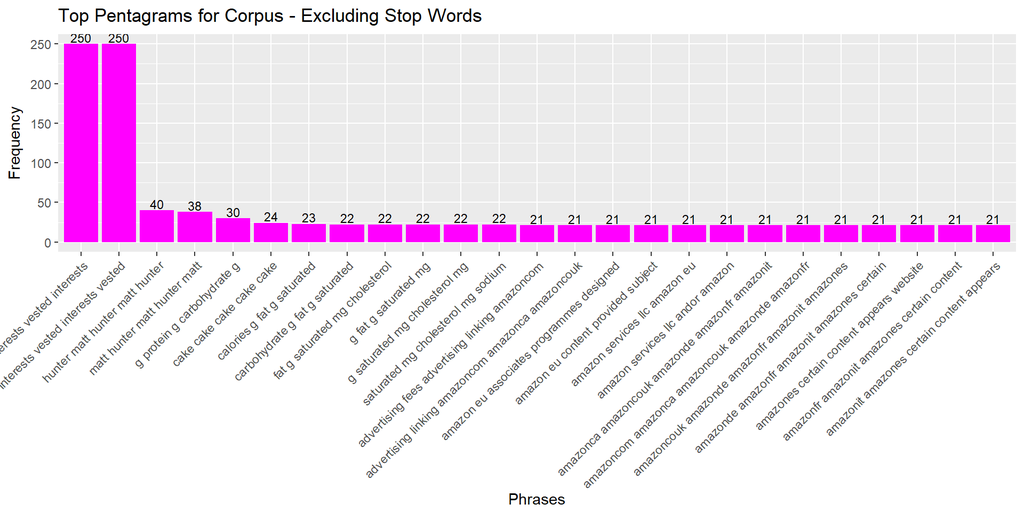

```r
# Create pentagram, with stops removed, and display top 25
pentagramws <- data.frame(table(make.ngrams(theCorpusWithoutStops, ngram.size = 5)))
colnames(pentagramws)<-c("Phrase","Frequency")
sortedPentagramws <- pentagramws[order(-pentagramws$Freq),]
topPentagramws <- sortedPentagramws[1:25,]
colnames(topPentagramws)<-c("Phrase","Frequency")
topPentagramws$Phrase <- factor(topPentagramws$Phrase, levels = topPentagramws$Phrase)

ggplot (topPentagramws, aes(x = Phrase, y= Frequency )) +
  geom_bar( stat = "Identity" , fill = "magenta" ) +
  geom_text( aes (label = Frequency ) , vjust = - 0.20, size = 3 ) +
  xlab( "Phrases" ) + ylab( "Frequency" ) +
  labs(title = "Top Pentagrams for Corpus - Excluding Stop Words") +
  theme ( axis.text.x = element_text ( angle = 45 , hjust = 1 ) )
```

### 6-grams

For 6-grams, only text containing stop words is used. The phrases present appear natural and seem like strong candidates for use in suggesting words. Phrases do still contain significant amounts of common words, which may limit the frequency of suggested words being non-stop words.

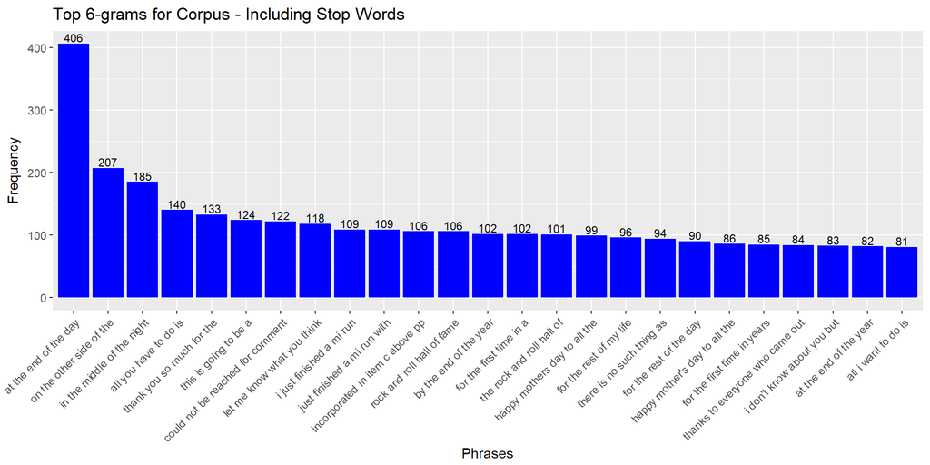

```r
# Create sixgram and display top 25
sixgram <- data.frame(table(make.ngrams(theCorpus5, ngram.size = 6)))
colnames(sixgram)<-c("Phrase","Frequency")
sortedSixgram <- sixgram[order(-sixgram$Freq),]
topSixgram <- sortedSixgram[1:25,]
colnames(topSixgram)<-c("Phrase","Frequency")
topSixgram$Phrase <- factor(topSixgram$Phrase, levels = topSixgram$Phrase)

ggplot (topSixgram, aes(x = Phrase, y= Frequency )) +
  geom_bar( stat = "Identity" , fill = "blue" ) +
  geom_text( aes (label = Frequency ) , vjust = - 0.20, size = 3 ) +
  xlab( "Phrases" ) + ylab( "Frequency" ) +
  labs(title = "Top 6-grams for Corpus - Including Stop Words") +
  theme ( axis.text.x = element_text ( angle = 45 , hjust = 1 ) )
```

# Combine N-grams to Constuct Prediction Table

The least frequent n-gram phrases are removed from each set. The last word in each phrase is seperated from the phrase to become the suggested word. When a particular row’s phrase is matched the final word can be suggested. The length of the phrase is also stored in the row. Suggested words will first be sorted by length of matched phrase and then secondly by frequency of the phrase.

### Clear Uncommon Words from N-grams

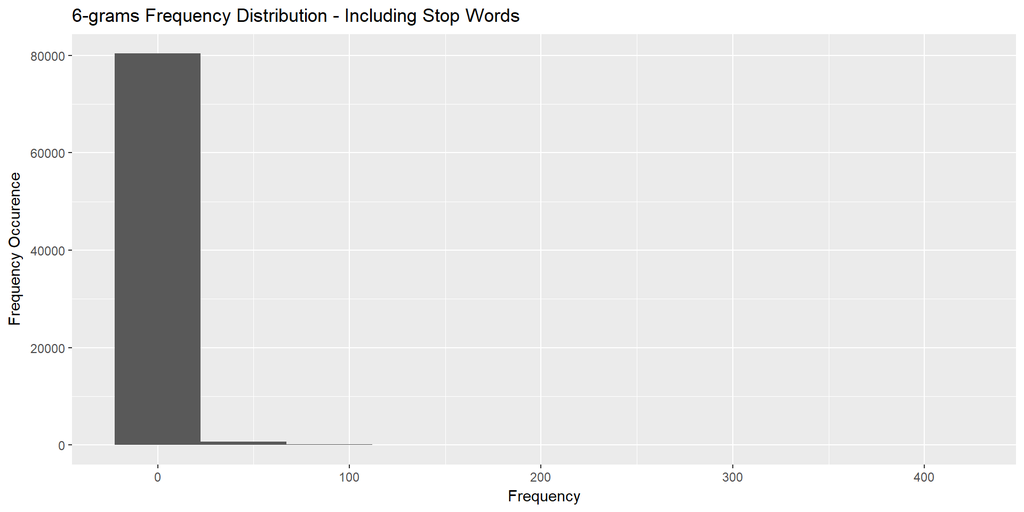

```r
# Clear uncommons
commons <- sortedSixgram$Freq > 2
sortedSixgram <- sortedSixgram[commons,]

ggplot (sortedSixgram, aes(sortedSixgram$Freq)) +
  geom_histogram(bins = 10) +
  xlab( "Frequency" ) + ylab( "Frequency Occurence" ) +
  labs(title = "6-grams Frequency Distribution - Including Stop Words")
```

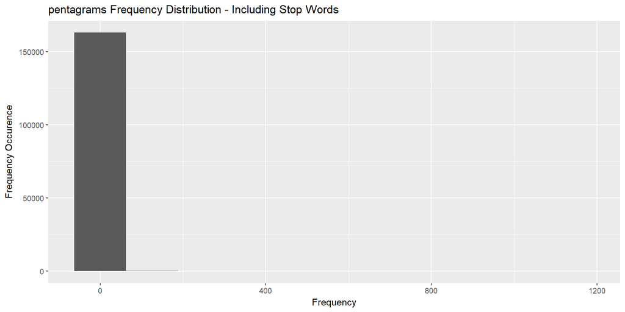

```r
# Clear uncommons
commons <- sortedPentagram$Freq > 2
sortedPentagram <- sortedPentagram[commons,]

ggplot (sortedPentagram, aes(sortedPentagram$Freq)) +
  geom_histogram(bins = 10) +
  xlab( "Frequency" ) + ylab( "Frequency Occurence" ) +
  labs(title = "pentagrams Frequency Distribution - Including Stop Words")
```

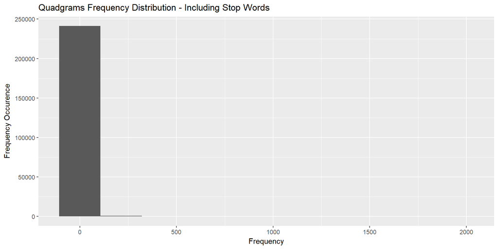

```r
# Clear uncommons
commons <- sortedQuadgram$Freq > 3
sortedQuadgram <- sortedQuadgram[commons,]

ggplot (sortedQuadgram, aes(sortedQuadgram$Freq)) +
  geom_histogram(bins = 10) +
  xlab( "Frequency" ) + ylab( "Frequency Occurence" ) +
  labs(title = "Quadgrams Frequency Distribution - Including Stop Words")
```

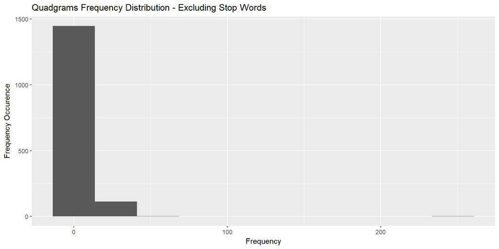

```r
# Clear uncommons
commons <- sortedQuadgramws$Freq > 3
sortedQuadgramws <- sortedQuadgramws[commons,]

ggplot (sortedQuadgramws, aes(sortedQuadgramws$Freq)) +
  geom_histogram(bins = 10) +
  xlab( "Frequency" ) + ylab( "Frequency Occurence" ) +
  labs(title = "Quadgrams Frequency Distribution - Excluding Stop Words")
```

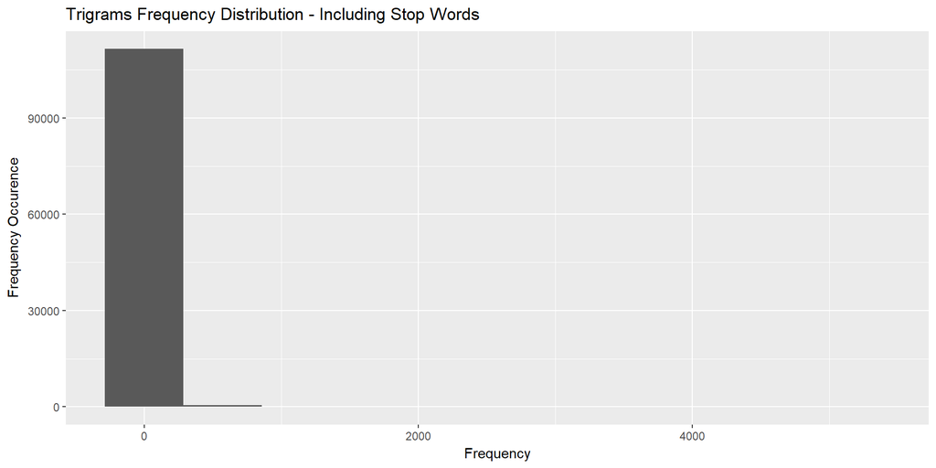

```r
# Clear uncommons
commons <- sortedTrigram$Freq > 8
sortedTrigram <- sortedTrigram[commons,]

ggplot (sortedTrigram, aes(sortedTrigram$Freq)) +
  geom_histogram(bins = 10) +
  xlab( "Frequency" ) + ylab( "Frequency Occurence" ) +
  labs(title = "Trigrams Frequency Distribution - Including Stop Words")
```

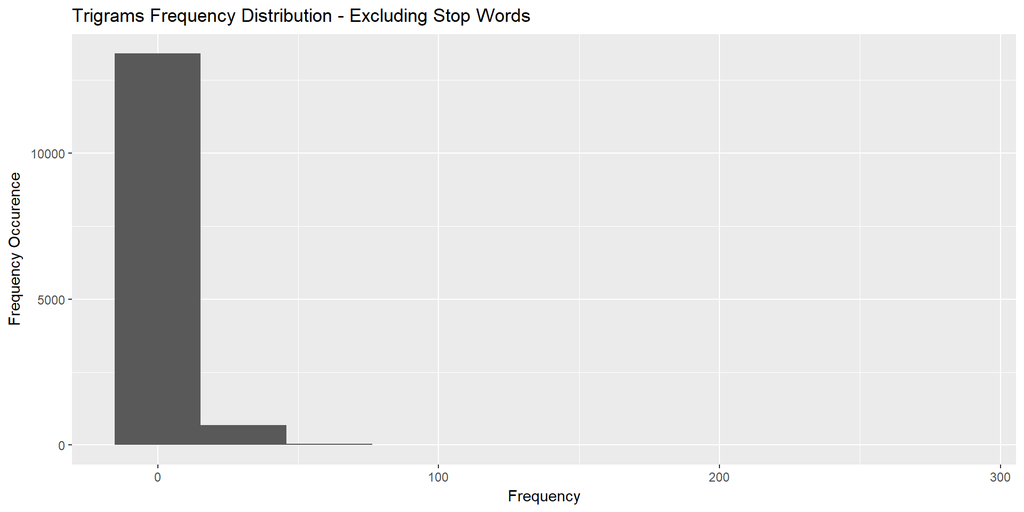

```r
# Clear uncommons
commons <- sortedTrigramws$Freq > 3
sortedTrigramws <- sortedTrigramws[commons,]

ggplot (sortedTrigramws, aes(sortedTrigramws$Freq)) +
  geom_histogram(bins = 10) +
  xlab( "Frequency" ) + ylab( "Frequency Occurence" ) +
  labs(title = "Trigrams Frequency Distribution - Excluding Stop Words")
```

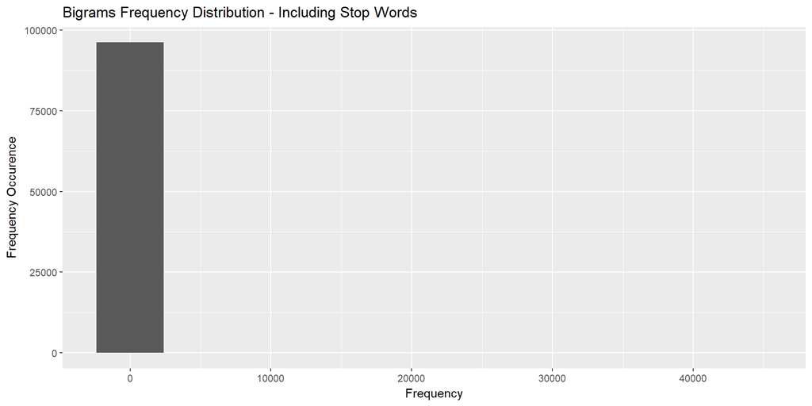

```r
# Clear uncommons
commons <- sortedBigram$Freq > 10
sortedBigram <- sortedBigram[commons,]

ggplot (sortedBigram, aes(sortedBigram$Freq)) +
  geom_histogram(bins = 10) +
  xlab( "Frequency" ) + ylab( "Frequency Occurence" ) +
  labs(title = "Bigrams Frequency Distribution - Including Stop Words")
```

[figure not shown]

```r
# Clear uncommons
commons <- sortedBigramws$Freq > 6
sortedBigramws <- sortedBigramws[commons,]

ggplot (sortedBigramws, aes(sortedBigramws$Freq)) +
  geom_histogram(bins = 10) +
  xlab( "Frequency" ) + ylab( "Frequency Occurence" ) +
  labs(title = "Bigrams Frequency Distribution - Including Stop Words")
```

### Split Last Word into Seperate Column

```r
# Create new column containing last word of phrase
#ends <- sapply(sortedSixgram$Phrase, stri_extract_last_words)
#sortedSixgram <- cbind(sortedSixgram, ends)
sortedSixgram$ends <- sortedSixgram$Phrase
sortedSixgram$ends <- gsub(sortedSixgram$ends, pattern = "[a-z']* ", replacement = "")
sortedSixgram$Phrase <- sub(sortedSixgram$Phrase, pattern = " [a-z']*$", replacement = "")
length <- rep(5, NROW(sortedSixgram))
sortedSixgram <- cbind(sortedSixgram, length)
head(sortedSixgram, 5)
```

```
##                         Phrase Frequency  ends length
## 4025445      at the end of the       406   day      5
## 23254338  on the other side of       207   the      5
## 16060542  in the middle of the       185 night      5
## 1688637     all you have to do       140    is      5
## 29950064 thank you so much for       133   the      5
```

```r
# Create new column containing last word of phrase
#ends <- sapply(sortedPentagram$Phrase, stri_extract_last_words)
#sortedPentagram <- cbind(sortedPentagram, ends)
sortedPentagram$ends <- sortedPentagram$Phrase
sortedPentagram$ends <- gsub(sortedPentagram$ends, pattern = "[a-z']* ", replacement = "")
sortedPentagram$Phrase <- sub(sortedPentagram$Phrase, pattern = " [a-z']*$", replacement = "")
length <- rep(4, NROW(sortedPentagram))
sortedPentagram <- cbind(sortedPentagram, length)
head(sortedPentagram, 5)
```

```
##                      Phrase Frequency ends length
## 2949347       at the end of      1133  the      4
## 11761804   in the middle of       541  the      4
## 8228143  for the first time       471   in      4
## 22700615     the end of the       414  day      4
## 4494407       by the end of       398  the      4
```

```r
# Create new column containing last word of phrase
#ends <- sapply(sortedQuadgram$Phrase, stri_extract_last_words)
#sortedQuadgram <- cbind(sortedQuadgram, ends)
sortedQuadgram$ends <- sortedQuadgram$Phrase
sortedQuadgram$ends <- gsub(sortedQuadgram$ends, pattern = "[a-z']* ", replacement = "")
sortedQuadgram$Phrase <- sub(sortedQuadgram$Phrase, pattern = " [a-z']*$", replacement = "")
length <- rep(3, NROW(sortedQuadgram))
sortedQuadgram <- cbind(sortedQuadgram, length)
head(sortedQuadgram, 5)
```

```
##                  Phrase Frequency   ends length
## 17408474     the end of      1933    the      3
## 2216746      at the end      1630     of      3
## 17870523    the rest of      1622    the      3
## 16906821 thanks for the      1568 follow      3
## 6366607   for the first      1530   time      3
```

```r
# Create new column containing last word of phrase
#ends <- sapply(sortedQuadgramws$Phrase, stri_extract_last_words)
#sortedQuadgramws <- cbind(sortedQuadgramws, ends)
sortedQuadgramws$ends <- sortedQuadgramws$Phrase
sortedQuadgramws$ends <- gsub(sortedQuadgramws$ends, pattern = "[a-z']* ", replacement = "")
sortedQuadgramws$Phrase <- sub(sortedQuadgramws$Phrase, pattern = " [a-z']*$", replacement = "")
length <- rep(3, NROW(sortedQuadgramws))
sortedQuadgramws <- cbind(sortedQuadgramws, length)
head(sortedQuadgramws, 5)
```

```
##                             Phrase Frequency      ends length
## 5094678    vested interests vested       251 interests      3
## 2288587 interests vested interests       250    vested      3
## 2855356         martin luther king        49        jr      3
## 1748234                    g fat g        48 saturated      3
## 2865291           matt hunter matt        43    hunter      3
```

```r
# Create new column containing last word of phrase
#ends <- sapply(sortedTrigram$Phrase, stri_extract_last_words)
#sortedTrigram <- cbind(sortedTrigram, ends)
sortedTrigram$ends <- sortedTrigram$Phrase
sortedTrigram$ends <- gsub(sortedTrigram$ends, pattern = "[a-z']* ", replacement = "")
sortedTrigram$Phrase <- sub(sortedTrigram$Phrase, pattern = " [a-z']*$", replacement = "")
length <- rep(2, NROW(sortedTrigram))
sortedTrigram <- cbind(sortedTrigram, length)
head(sortedTrigram, 5)
```

```
##             Phrase Frequency ends length
## 5972859     one of      5161  the      2
## 100009       a lot      4434   of      2
## 7884483 thanks for      3504  the      2
## 8653942      to be      2813    a      2
## 3312527   going to      2675   be      2
```

```r
# Create new column containing last word of phrase
#ends <- sapply(sortedTrigramws$Phrase, stri_extract_last_words)
#sortedTrigramws <- cbind(sortedTrigramws, ends)
sortedTrigramws$ends <- sortedTrigramws$Phrase
sortedTrigramws$ends <- gsub(sortedTrigramws$ends, pattern = "[a-z']* ", replacement = "")
sortedTrigramws$Phrase <- sub(sortedTrigramws$Phrase, pattern = " [a-z']*$", replacement = "")
length <- rep(2, NROW(sortedTrigramws))
sortedTrigramws <- cbind(sortedTrigramws, length)
head(sortedTrigramws, 5)
```

```
##                   Phrase Frequency      ends length
## 3062780         new york       279      city      2
## 2506685           let us       260      know      2
## 2228741 interests vested       251 interests      2
## 4944797 vested interests       251    vested      2
## 1974670        happy new       172      year      2
```

```r
# Create new column containing last word of phrase
#ends <- sapply(sortedBigram$Phrase, stri_extract_last_words)
#sortedBigram <- cbind(sortedBigram, ends)
sortedBigram$ends <- sortedBigram$Phrase
sortedBigram$ends <- gsub(sortedBigram$ends, pattern = "[a-z']* ", replacement = "")
sortedBigram$Phrase <- sub(sortedBigram$Phrase, pattern = " [a-z']*$", replacement = "")
length <- rep(1, NROW(sortedBigram))
sortedBigram <- cbind(sortedBigram, length)
head(sortedBigram, 5)
```

```
##         Phrase Frequency ends length
## 1735008     of     43203  the      1
## 1226728     in     41482  the      1
## 2570969     to     21631  the      1
## 929084     for     19959  the      1
## 1763551     on     19591  the      1
```

```r
# Create new column containing last word of phrase
#ends <- sapply(sortedBigramws$Phrase, stri_extract_last_words)
#sortedBigramws <- cbind(sortedBigramws, ends)
sortedBigramws$ends <- sortedBigramws$Phrase
sortedBigramws$ends <- gsub(sortedBigramws$ends, pattern = "[a-z']* ", replacement = "")
sortedBigramws$Phrase <- sub(sortedBigramws$Phrase, pattern = " [a-z']*$", replacement = "")
length <- rep(1, NROW(sortedBigramws))
sortedBigramws <- cbind(sortedBigramws, length)
head(sortedBigramws, 5)
```

```
##         Phrase Frequency   ends length
## 2610071  right      2525    now      1
## 2076361    new      2034   york      1
## 1688929   last      1820   year      1
## 1688247   last      1508  night      1
## 1412553   high      1400 school      1
```

### Scale Frequency Based on Word Catergory

```r
# Half frequency of stop words and resort tables
stopSpots <- grep(modStops, sortedSixgram$ends)
sortedSixgram$Frequency[stopSpots] <- sortedSixgram$Frequency[stopSpots] / 2
sortedSixgram <- sortedSixgram[order(-sortedSixgram$Freq),]

stopSpots <- grep(modStops, sortedPentagram$ends)
sortedPentagram$Frequency[stopSpots] <- sortedPentagram$Frequency[stopSpots] / 2
sortedPentagram <- sortedPentagram[order(-sortedPentagram$Freq),]

stopSpots <- grep(modStops, sortedQuadgram$ends)
sortedQuadgram$Frequency[stopSpots] <- sortedQuadgram$Frequency[stopSpots] / 2
sortedQuadgram <- sortedQuadgram[order(-sortedQuadgram$Freq),]

stopSpots <- grep(modStops, sortedTrigram$ends)
sortedTrigram$Frequency[stopSpots] <- sortedTrigram$Frequency[stopSpots] / 2
sortedTrigram <- sortedTrigram[order(-sortedTrigram$Freq),]

stopSpots <- grep(modStops, sortedBigram$ends)
sortedBigram$Frequency[stopSpots] <- sortedBigram$Frequency[stopSpots] / 2
sortedBigram <- sortedBigram[order(-sortedBigram$Freq),]
```

### Create Default Output Table

```r
# Create defualt table
defaultSuggests <- c("is", "a", "to", "the", "and", "for", "with", "from", "by", "or")
```

# Example Code for Prediction from tables

A functional excerpt of the code from the main loop of the prediction algorithm for finding word suggestions from a supplied phrase. The input phrase is parsed and then matched against the phrases in th repdiction tables. The search is halted once ten matches have been found. The top results are then compiled into an output string.

The final source code, for both the ui.R and server.R, can be found at: https://github.com/Eric-Henderson-127/DataScienceCapstone

```r
# Test run
sentence <- "An example for this is a"
phrase <- sentence
sentence <- unlist(strsplit(sentence, split=" "))
sentence <- sapply(sentence, tolower)
sentence <- gsub("[^'[:lower:]]", "", sentence)
sentence <- gsub("â|€|™|˜|œ|„|Â", "", sentence)
sentence <- gsub("^'*$", "", sentence)
sentence <- gsub("^'s$", "", sentence)
numsAndEmpty <- grep("^[[:digit:]]*$", sentence)
if(length(numsAndEmpty) > 0)
{
  sentence <- sentence[-numsAndEmpty]
}
results <- data.frame(Phrase=character(),
                      Frequency=integer(),
                      ends=character(),
                      length=integer())
if(length(sentence) > 5)
{
  trim <- (length(sentence) - 5) + 1
  sentence <- sentence[trim:length(sentence)]
}
if(length(sentence) == 5 && NROW(results) < 10)
{
  tempSentence <- paste(sentence, collapse = " ")
  tempSentence <- paste("^", tempSentence, "$")
  tempSentence <- sub("\\^ ", "^", tempSentence)
  tempSentence <- sub(" \\$", "$", tempSentence)
  temp <- grep(tempSentence, sortedSixgram$Phrase)
  results <- rbind(results, sortedSixgram[temp,])
  sentence <- sentence[2:length(sentence)]
}
if(length(sentence) == 4 && NROW(results) < 10)
{
  tempSentence <- paste(sentence, collapse = " ")
  tempSentence <- paste("^", tempSentence, "$")
  tempSentence <- sub("\\^ ", "^", tempSentence)
  tempSentence <- sub(" \\$", "$", tempSentence)
  temp <- grep(paste(tempSentence, collapse = " "), sortedPentagram$Phrase)
  results <- rbind(results, sortedPentagram[temp,])
  sentence <- sentence[2:length(sentence)]
}
if(length(sentence) == 3 && NROW(results) < 10)
{
  tempSentence <- paste(sentence, collapse = " ")
  tempSentence <- paste("^", tempSentence, "$")
  tempSentence <- sub("\\^ ", "^", tempSentence)
  tempSentence <- sub(" \\$", "$", tempSentence)
  temp <- grep(paste(tempSentence, collapse = " "), sortedQuadgram$Phrase)
  results <- rbind(results, sortedQuadgram[temp,])
  sentence <- sentence[2:length(sentence)]
}
if(length(sentence) == 2 && NROW(results) < 10)
{
  tempSentence <- paste(sentence, collapse = " ")
  tempSentence <- paste("^", tempSentence, "$")
  tempSentence <- sub("\\^ ", "^", tempSentence)
  tempSentence <- sub(" \\$", "$", tempSentence)
  temp <- grep(paste(tempSentence, collapse = " "), sortedTrigram$Phrase)
  results <- rbind(results, sortedTrigram[temp,])
  sentence <- sentence[2:length(sentence)]
}
if(length(sentence) == 1 && NROW(results) < 10)
{
  tempSentence <- paste(sentence, collapse = " ")
  tempSentence <- paste("^", tempSentence, "$")
  tempSentence <- sub("\\^ ", "^", tempSentence)
  tempSentence <- sub(" \\$", "$", tempSentence)
  temp <- grep(paste(tempSentence, collapse = " "), sortedBigram$Phrase)
  results <- rbind(results, sortedBigram[temp,])
}
if(NROW(results) >= 10)
{
  theSubset <- results[1:10,]
}
if(NROW(results) < 10)
{
  theSubset <- results[1:NROW(results),]
}
if(is.na(theSubset$ends[1]))
{
  theSubset <- theSubset[-1,]
}
if(length(theSubset) > 0)
{
  suggested <- as.character(theSubset$ends)
  suggested <- c(suggested, defaultSuggests)
  suggested <- unique(suggested)
}
if(length(theSubset) == 0)
{
  suggested <- defaultSuggests
}

if(length(suggested) >= 5)
{
  suggested <- suggested[1:5]
}
if(length(suggested) < 5)
{
  suggested <- suggested[1:length(suggested)]
}
theSubset <- theSubset[1:5,]
saveRDS(phrase, "phraseData.rds")
saveRDS(suggested, "suggestedData.rds")
saveRDS(theSubset, "subsetData.rds")
suggested
```

```
## [1] "great" "good"  "big"   "very"  "new"
```

# Export Prediction Tables

Finally, the constructed prediction tables are written out to CSV files to be used by the shiny application.

```r
# Export tables
write.csv(sortedSixgram, file = "data/prediction_table_sixgram.csv", row.names = FALSE)
write.csv(sortedPentagram, file = "data/prediction_table_pentagram.csv", row.names = FALSE)
write.csv(sortedQuadgram, file = "data/prediction_table_quadgram.csv", row.names = FALSE)
write.csv(sortedTrigram, file = "data/prediction_table_trigram.csv", row.names = FALSE)
write.csv(sortedBigram, file = "data/prediction_table_bigram.csv", row.names = FALSE)
```